# Project 1: Investigating the Dataset : noshowappointments

- Introduction
- Question Section
- Data Wrangling
- Exploratory Data Analysis
- Conclusions

## Questions to be answered

> 1. Is the abscence higher in a gender more than another?  
> 2. Is the abscence higher in older age than younger ones?  
> 3. Is showing up higher in a specific period/date/month more than another?  
> Is showing up higher when schedule date and appointment date are the same?  
> 4. Is the abscence higher for specific neighbours more than others?  
> 5. Do people having scholarship attend more to their consultation because it is free  
> 6. Does the abscence dependent on the type of the disease is it an emergency or not : (Hipertension, Diabetes , Alcoholism, Handcap)  
> 7. Do people receiving SMS tned to show up more than others?

```python
#importing needed packages
import numpy as np
import pandas as pd
import matplotlib.pyplot as plt
import seaborn as sns
from datetime import datetime

%matplotlib inline
sns.set_style('darkgrid')
#loading the dataset
df=pd.read_csv('Database_No_show_appointments.csv')
```

```python
#Upgrade pandas to use dataframe.explode() function.
#!pip install --upgrade pandas
```

## Data Wrangling

```python
# Loading my data and print out 10 lines.
df.head(11)
```

|  | PatientId | AppointmentID | Gender | ScheduledDay | AppointmentDay | Age | Neighbourhood | Scholarship | Hipertension | Diabetes | Alcoholism | Handcap | SMS_received | No-show |
| --- | --- | --- | --- | --- | --- | --- | --- | --- | --- | --- | --- | --- | --- | --- |
| 0 | 2.987250e+13 | 5642903 | F | 2016-04-29T18:38:08Z | 2016-04-29T00:00:00Z | 62 | JARDIM DA PENHA | 0 | 1 | 0 | 0 | 0 | 0 | No |
| 1 | 5.589978e+14 | 5642503 | M | 2016-04-29T16:08:27Z | 2016-04-29T00:00:00Z | 56 | JARDIM DA PENHA | 0 | 0 | 0 | 0 | 0 | 0 | No |
| 2 | 4.262962e+12 | 5642549 | F | 2016-04-29T16:19:04Z | 2016-04-29T00:00:00Z | 62 | MATA DA PRAIA | 0 | 0 | 0 | 0 | 0 | 0 | No |
| 3 | 8.679512e+11 | 5642828 | F | 2016-04-29T17:29:31Z | 2016-04-29T00:00:00Z | 8 | PONTAL DE CAMBURI | 0 | 0 | 0 | 0 | 0 | 0 | No |
| 4 | 8.841186e+12 | 5642494 | F | 2016-04-29T16:07:23Z | 2016-04-29T00:00:00Z | 56 | JARDIM DA PENHA | 0 | 1 | 1 | 0 | 0 | 0 | No |
| 5 | 9.598513e+13 | 5626772 | F | 2016-04-27T08:36:51Z | 2016-04-29T00:00:00Z | 76 | REPÚBLICA | 0 | 1 | 0 | 0 | 0 | 0 | No |
| 6 | 7.336882e+14 | 5630279 | F | 2016-04-27T15:05:12Z | 2016-04-29T00:00:00Z | 23 | GOIABEIRAS | 0 | 0 | 0 | 0 | 0 | 0 | Yes |
| 7 | 3.449833e+12 | 5630575 | F | 2016-04-27T15:39:58Z | 2016-04-29T00:00:00Z | 39 | GOIABEIRAS | 0 | 0 | 0 | 0 | 0 | 0 | Yes |
| 8 | 5.639473e+13 | 5638447 | F | 2016-04-29T08:02:16Z | 2016-04-29T00:00:00Z | 21 | ANDORINHAS | 0 | 0 | 0 | 0 | 0 | 0 | No |
| 9 | 7.812456e+13 | 5629123 | F | 2016-04-27T12:48:25Z | 2016-04-29T00:00:00Z | 19 | CONQUISTA | 0 | 0 | 0 | 0 | 0 | 0 | No |
| 10 | 7.345362e+14 | 5630213 | F | 2016-04-27T14:58:11Z | 2016-04-29T00:00:00Z | 30 | NOVA PALESTINA | 0 | 0 | 0 | 0 | 0 | 0 | No |

```python
#let's see the description of our dataset
df.describe()
```

|  | PatientId | AppointmentID | Age | Scholarship | Hipertension | Diabetes | Alcoholism | Handcap | SMS_received |
| --- | --- | --- | --- | --- | --- | --- | --- | --- | --- |
| count | 1.105270e+05 | 1.105270e+05 | 110527.000000 | 110527.000000 | 110527.000000 | 110527.000000 | 110527.000000 | 110527.000000 | 110527.000000 |
| mean | 1.474963e+14 | 5.675305e+06 | 37.088874 | 0.098266 | 0.197246 | 0.071865 | 0.030400 | 0.022248 | 0.321026 |
| std | 2.560949e+14 | 7.129575e+04 | 23.110205 | 0.297675 | 0.397921 | 0.258265 | 0.171686 | 0.161543 | 0.466873 |
| min | 3.921784e+04 | 5.030230e+06 | -1.000000 | 0.000000 | 0.000000 | 0.000000 | 0.000000 | 0.000000 | 0.000000 |
| 25% | 4.172614e+12 | 5.640286e+06 | 18.000000 | 0.000000 | 0.000000 | 0.000000 | 0.000000 | 0.000000 | 0.000000 |
| 50% | 3.173184e+13 | 5.680573e+06 | 37.000000 | 0.000000 | 0.000000 | 0.000000 | 0.000000 | 0.000000 | 0.000000 |
| 75% | 9.439172e+13 | 5.725524e+06 | 55.000000 | 0.000000 | 0.000000 | 0.000000 | 0.000000 | 0.000000 | 1.000000 |
| max | 9.999816e+14 | 5.790484e+06 | 115.000000 | 1.000000 | 1.000000 | 1.000000 | 1.000000 | 4.000000 | 1.000000 |

The 'PatientId' and 'AppointmentID' descriptions are not useful

**We can drop them**

Let's now check for missing values

```python
#comparing the sample size to the count in each column
print("shape = ",df.shape)
print(df.info())
```

```
shape =  (110527, 14)
<class 'pandas.core.frame.DataFrame'>
RangeIndex: 110527 entries, 0 to 110526
Data columns (total 14 columns):
 #   Column          Non-Null Count   Dtype
---  ------          --------------   -----
 0   PatientId       110527 non-null  float64
 1   AppointmentID   110527 non-null  int64
 2   Gender          110527 non-null  object
 3   ScheduledDay    110527 non-null  object
 4   AppointmentDay  110527 non-null  object
 5   Age             110527 non-null  int64
 6   Neighbourhood   110527 non-null  object
 7   Scholarship     110527 non-null  int64
 8   Hipertension    110527 non-null  int64
 9   Diabetes        110527 non-null  int64
 10  Alcoholism      110527 non-null  int64
 11  Handcap         110527 non-null  int64
 12  SMS_received    110527 non-null  int64
 13  No-show         110527 non-null  object
dtypes: float64(1), int64(8), object(5)
memory usage: 11.8+ MB
None
```

**We don't have missing values**

(the number of appointements is equal to the number of rows we have in each column)

```python
#checking for null values
df.isnull().sum()
```

```
PatientId         0
AppointmentID     0
Gender            0
ScheduledDay      0
AppointmentDay    0
Age               0
Neighbourhood     0
Scholarship       0
Hipertension      0
Diabetes          0
Alcoholism        0
Handcap           0
SMS_received      0
No-show           0
dtype: int64
```

**We don't have null values**

```python
#checking for duplicated
df[df.duplicated()].sum()
```

```
PatientId         0.0
AppointmentID     0.0
Gender            0.0
ScheduledDay      0.0
AppointmentDay    0.0
Age               0.0
Neighbourhood     0.0
Scholarship       0.0
Hipertension      0.0
Diabetes          0.0
Alcoholism        0.0
Handcap           0.0
SMS_received      0.0
No-show           0.0
dtype: float64
```

**We don't have duplicated values**

```python
#checking the column names format
df.columns
```

```
Index(['PatientId', 'AppointmentID', 'Gender', 'ScheduledDay',
       'AppointmentDay', 'Age', 'Neighbourhood', 'Scholarship', 'Hipertension',
       'Diabetes', 'Alcoholism', 'Handcap', 'SMS_received', 'No-show'],
      dtype='object')
```

It is easier to have the columns' name in lower case and seperated by "_" instead of a space

**I will rename the column names and remove the dash from no-show column**

```python
#checking if data types are appropriate
df.dtypes
```

```
PatientId         float64
AppointmentID       int64
Gender             object
ScheduledDay       object
AppointmentDay     object
Age                 int64
Neighbourhood      object
Scholarship         int64
Hipertension        int64
Diabetes            int64
Alcoholism          int64
Handcap             int64
SMS_received        int64
No-show            object
dtype: object
```

**We have two inapropriate values**

scheduledday object  
appointmentday object

### Data Cleaning

**Replacing the age outlier -1 to 0**

```python
#replacing the -1 outlier in age to 0
df["Age"].replace({-1 : 0}, inplace=True)
#checking the result
df.query('Age == -1')
```

|  | PatientId | AppointmentID | Gender | ScheduledDay | AppointmentDay | Age | Neighbourhood | Scholarship | Hipertension | Diabetes | Alcoholism | Handcap | SMS_received | No-show |
| --- | --- | --- | --- | --- | --- | --- | --- | --- | --- | --- | --- | --- | --- | --- |

```python
#check for the min age value
df['Age'].describe()
```

```
count    110527.000000
mean         37.088883
std          23.110190
min           0.000000
25%          18.000000
50%          37.000000
75%          55.000000
max         115.000000
Name: Age, dtype: float64
```

**The min value now is 0**

It seems logic

Now

**I will rename the column**

```python
#applying replace and lower to columns' name
df.columns= df.columns.str.replace(' ','_')
df.columns= df.columns.str.lower()
df.columns= df.columns.str.replace('-','_')
df.columns
```

```
Index(['patientid', 'appointmentid', 'gender', 'scheduledday',
       'appointmentday', 'age', 'neighbourhood', 'scholarship', 'hipertension',
       'diabetes', 'alcoholism', 'handcap', 'sms_received', 'no_show'],
      dtype='object')
```

Next step is

**Extracting the "%y-%m-%d" and changing the type to date**

```python
#Changing the data types of scheduled day and appointment day from string to date

df['scheduledday']=pd.to_datetime(df['scheduledday'])
df['dateschedule']=df['scheduledday'].dt.date
#extracting the day/month/year format from date appointement and creating a new column for it
df['appointmentday']=pd.to_datetime(df['appointmentday'])
#extracting the month from date schedule and creating a new column for it
df['dateappointement']=df['appointmentday'].dt.date
#checking
df.head()
```

|  | patientid | appointmentid | gender | scheduledday | appointmentday | age | neighbourhood | scholarship | hipertension | diabetes | alcoholism | handcap | sms_received | no_show | dateschedule | dateappointement |
| --- | --- | --- | --- | --- | --- | --- | --- | --- | --- | --- | --- | --- | --- | --- | --- | --- |
| 0 | 2.987250e+13 | 5642903 | F | 2016-04-29 18:38:08+00:00 | 2016-04-29 00:00:00+00:00 | 62 | JARDIM DA PENHA | 0 | 1 | 0 | 0 | 0 | 0 | No | 2016-04-29 | 2016-04-29 |
| 1 | 5.589978e+14 | 5642503 | M | 2016-04-29 16:08:27+00:00 | 2016-04-29 00:00:00+00:00 | 56 | JARDIM DA PENHA | 0 | 0 | 0 | 0 | 0 | 0 | No | 2016-04-29 | 2016-04-29 |
| 2 | 4.262962e+12 | 5642549 | F | 2016-04-29 16:19:04+00:00 | 2016-04-29 00:00:00+00:00 | 62 | MATA DA PRAIA | 0 | 0 | 0 | 0 | 0 | 0 | No | 2016-04-29 | 2016-04-29 |
| 3 | 8.679512e+11 | 5642828 | F | 2016-04-29 17:29:31+00:00 | 2016-04-29 00:00:00+00:00 | 8 | PONTAL DE CAMBURI | 0 | 0 | 0 | 0 | 0 | 0 | No | 2016-04-29 | 2016-04-29 |
| 4 | 8.841186e+12 | 5642494 | F | 2016-04-29 16:07:23+00:00 | 2016-04-29 00:00:00+00:00 | 56 | JARDIM DA PENHA | 0 | 1 | 1 | 0 | 0 | 0 | No | 2016-04-29 | 2016-04-29 |

```python
#extracting the month from date appointement
df['month_appoin'] = pd.DatetimeIndex(df['dateappointement']).month
df['month_appoin'].unique()
```

```
array([4, 5, 6], dtype=int64)
```

```python
#extracting the month from date schedule
df['month_sched'] = pd.DatetimeIndex(df['dateschedule']).month
df['month_sched'].unique()
```

```
array([ 4,  3,  2,  1,  5, 11, 12,  6], dtype=int64)
```

Now

**I can now drop the columns I will not need for the analysis**

```python
df.drop(['appointmentid','patientid','appointmentday','scheduledday'],axis=1,inplace=True)
df.head()
```

|  | gender | age | neighbourhood | scholarship | hipertension | diabetes | alcoholism | handcap | sms_received | no_show | dateschedule | dateappointement | month_appoin | month_sched |
| --- | --- | --- | --- | --- | --- | --- | --- | --- | --- | --- | --- | --- | --- | --- |
| 0 | F | 62 | JARDIM DA PENHA | 0 | 1 | 0 | 0 | 0 | 0 | No | 2016-04-29 | 2016-04-29 | 4 | 4 |
| 1 | M | 56 | JARDIM DA PENHA | 0 | 0 | 0 | 0 | 0 | 0 | No | 2016-04-29 | 2016-04-29 | 4 | 4 |
| 2 | F | 62 | MATA DA PRAIA | 0 | 0 | 0 | 0 | 0 | 0 | No | 2016-04-29 | 2016-04-29 | 4 | 4 |
| 3 | F | 8 | PONTAL DE CAMBURI | 0 | 0 | 0 | 0 | 0 | 0 | No | 2016-04-29 | 2016-04-29 | 4 | 4 |
| 4 | F | 56 | JARDIM DA PENHA | 0 | 1 | 1 | 0 | 0 | 0 | No | 2016-04-29 | 2016-04-29 | 4 | 4 |

```python
#chechking if the data types are correct now
df.dtypes
```

```
gender              object
age                  int64
neighbourhood       object
scholarship          int64
hipertension         int64
diabetes             int64
alcoholism           int64
handcap              int64
sms_received         int64
no_show             object
dateschedule        object
dateappointement    object
month_appoin         int64
month_sched          int64
dtype: object
```

**By now the data is clean I suppose**

## Exploratory Data Analysis

### General visualization

To go back to the questions section click here

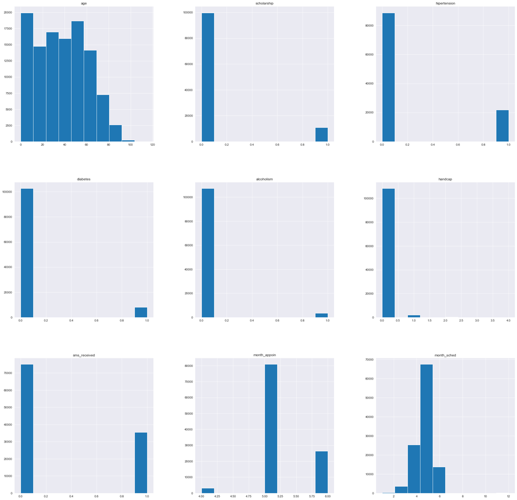

```python
df.hist(figsize=(30,30), alpha=1);
```

1)These visualizations show that:

[output not shown]

Let's see some catgorical variables' graphs

```python
#The frequency of showing up or not showing up
no_show= df['no_show'].value_counts()
no_show
```

```
No     88208
Yes    22319
Name: no_show, dtype: int64
```

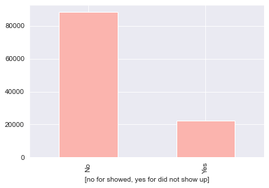

```python
#ploting the frequency of showing up or not among the patients sample
no_show.plot(kind='bar',xlabel=['no for showed',"yes for did not show up"],colormap='Pastel1');
plt.show();
```

2) more than 80000 patient show up as compared to 20000 who did not show up

```python
#the number of female and male from the population
gender_distribution= df['gender'].value_counts()/df['gender'].count()
gender_distribution
```

```
F    0.649977
M    0.350023
Name: gender, dtype: float64
```

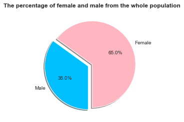

```python
#plotting the percentage of female and male from the whole population
plt.pie(gender_distribution, labels = ['Female', 'Male'], colors=['lightpink','deepskyblue'],
startangle=270, shadow = True, explode = (0, 0.1),
radius = 1.0, autopct = '%1.1f%%')
# plot title
plt.title('The percentage of female and male from the whole population', fontweight="bold")
# showing the plot
plt.show();
```

3)The number of females is 65% while the number of males is 35%

### To answer the first question

> Is the abscence higher in a gender more than another?

To go back to the questions section click here

```python
#Grouping the dataset by gender and no-show
gender_noshow = df.groupby('gender')['no_show'].value_counts()
gender_noshow
```

```
gender  no_show
F       No         57246
        Yes        14594
M       No         30962
        Yes         7725
Name: no_show, dtype: int64
```

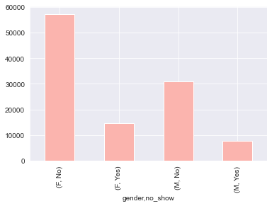

```python
#plotting a bar chart that counts the gender by no-show
gender_noshow.plot(kind= 'bar',colormap='Pastel1');
```

As the number of male and female are different we can not get an accurate answer

Let's calculate the proportion for each sample

```python
#calculating the total number of females and males
gender_totals = df.gender.value_counts()
gender_totals
```

```
F    71840
M    38687
Name: gender, dtype: int64
```

```python
# get proportions by dividing female sample counts by no-show over the total female sample
female_proportions = gender_noshow['F']/gender_totals['F']
female_proportions
```

```
no_show
No     0.796854
Yes    0.203146
Name: no_show, dtype: float64
```

```python
# get proportions by dividing male sample counts by no-show over the total male sample
male_proportions = gender_noshow['M']/gender_totals['M']
male_proportions
```

```
no_show
No     0.800321
Yes    0.199679
Name: no_show, dtype: float64
```

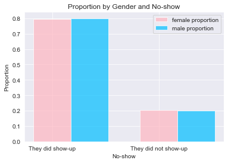

```python
ind = np.arange(len(male_proportions))  # the x locations for the groups
width = 0.35       # the width of the bars
ind
# plot bars
female_bars = plt.bar(['They did show-up', 'They did not show-up'], female_proportions, width, color='lightpink', alpha=.7, label='female proportion')
male_bars = plt.bar(ind+ width, male_proportions, width, color='deepskyblue', alpha=.7, label='male proportion')

# title and labels
plt.ylabel('Proportion')
plt.xlabel('No-show')
plt.title('Proportion by Gender and No-show')
locations = ind + width / 2  # xtick locations
labels = ['3', '4', '5', '6', '7', '8', '9']  # xtick labels
# legend
plt.legend();
```

80% of male showed up VS 79.6% of female who did show up (the percentages are so close )

## To answer the second question

> Is the abscence higher in older age than younger ones?

To go back to the questions section click here

```python
#we will use the median to split the values
print(df['age'].median())
```

```
37.0
```

```python
#creating seperate df for young and old patient based on the median value
young = df.query('age< 37')
old= df.query('age >= 37')
```

```python
#Is the sample of young patient equals that of old one?
young_total =young.shape[0]
old_total=old.shape[0]
print("sample of young patients = ",young_total)
print("sample of old   patients = ",old_total)
```

```
sample of young patients =  54584
sample of old   patients =  55943
```

```python
#I will use the same previous method to get the count of young and old patients by no-show
young_counts= young['no_show'].value_counts()
old_counts = old['no_show'].value_counts()
print(young_counts)
print(old_counts)
```

```
No     42140
Yes    12444
Name: no_show, dtype: int64
No     46068
Yes     9875
Name: no_show, dtype: int64
```

```python
#Calculating the proportion of young patients by no-show over the total number of young patients
young_propor = young_counts/young_total
young_propor
```

```
No     0.772021
Yes    0.227979
Name: no_show, dtype: float64
```

```python
#calculation the proportion of old patients by no-show over the total number of old patients
old_propor = old_counts/old_total
old_propor
```

```
No     0.823481
Yes    0.176519
Name: no_show, dtype: float64
```

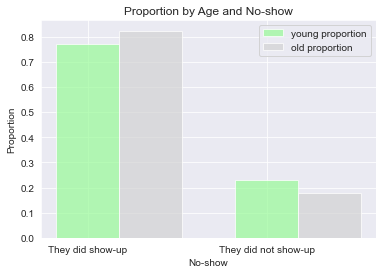

```python
# ploting young and old bars
ind = np.arange(len(young_propor))  # the x locations for the groups
width = 0.35       # the width of the bars
ind
young_bars = plt.bar(['They did show-up', 'They did not show-up'], young_propor, width, color='palegreen', alpha=.7, label='young proportion')
old_bars = plt.bar(ind + width, old_propor, width, color='lightgrey', alpha=.7, label='old proportion')

# title and labels
plt.ylabel('Proportion')
plt.xlabel('No-show')
plt.title('Proportion by Age and No-show')
locations = ind + width / 2  # xtick locations
labels = ['3', '4', '5', '6', '7', '8', '9']  # xtick labels
# legend
plt.legend();
```

The plot shows difference between young and old patients who showed up or not to their appointment </br> </br> </br> from the graph 82% of old people showed up to their appointment compared to 77% of young ones who show up</br> </br>

## To answer the third question

> Is showing up higher in a specific month more than another?

To go back to the questions section click here

```python
#Grouping dataset by month and no-show
df_month_appointement = df.groupby('month_appoin')['no_show'].value_counts()
df_month_appointement
```

```
month_appoin  no_show
4             No          2602
              Yes          633
5             No         64037
              Yes        16804
6             No         21569
              Yes         4882
Name: no_show, dtype: int64
```

### Before plotting the graph I would like to define a function for ploting so that I will have the same theme all over the notebook and without re-writing the ploting code each time

```python
def pie_chart(title,expression_to_plot):
    plt.pie(expression_to_plot, labels = ['show-up', 'no show-up'], colors=['palegreen', 'lightgrey'],
    startangle=270, shadow = True, explode = (0, 0.1),
    radius = 1.0, autopct = '%1.1f%%')
    # plot title
    plt.title(title, fontweight="bold")
    # showing the plot
    plt.show()
```

```
For month =  4 th month
```

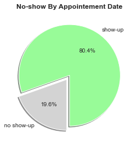

```
For month =  5 th month
```

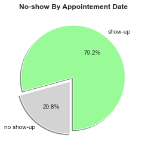

```
For month =  6 th month
```

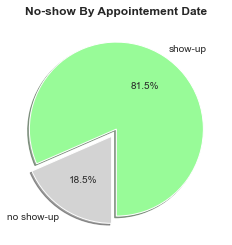

```python
#Extracting the different months of appointements in the data set
month_values = df['month_appoin'].unique()
#ploting a pie chart for each month
for i in month_values:
    print( "For month = ",i,"th month")
    #using the previous function: pie_chart(title,expression_to_plot)
    pie_chart('No-show By Appointement Date',df_month_appointement[i])
```

The percentages of people who show up and not show up in all appointment months are respectively and approximately 80% and 20%

## Additional question to answer

> Do people who have schedule date and appointment date on the smae date tend to attend more than other

To go back to the questions section click here

```python
#creating a df in which schedule date equals to appointement date
df_date = df.query("dateschedule==dateappointement")

#creating a df in which schedule date is different from appointement date
df_different_date = df.query("dateschedule!=dateappointement")
```

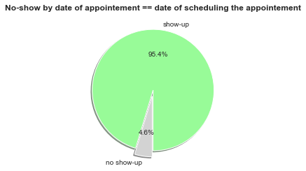

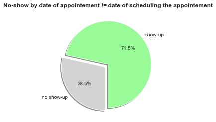

```python
#using the previous function to plot a pie chart, the function is: pie_chart(title,expression_to_plot)
pie_chart('No-show by date of appointement == date of scheduling the appointement',df_date['no_show'].value_counts())
pie_chart('No-show by date of appointement != date of scheduling the appointement',df_different_date['no_show'].value_counts())
```

## Fourth question to answer

> Is the abscence higher for specific neighbours more than others?

To go back to the questions section click here

```python
#Grouping dataset by neighborhood and no-show
df_neigh =df.groupby('neighbourhood')['no_show'].value_counts()
df_neigh
```

```
neighbourhood    no_show
AEROPORTO        No            7
                 Yes           1
ANDORINHAS       No         1741
                 Yes         521
ANTÔNIO HONÓRIO  No          221
                            ...
TABUAZEIRO       Yes         573
UNIVERSITÁRIO    No          120
                 Yes          32
VILA RUBIM       No          710
                 Yes         141
Name: no_show, Length: 160, dtype: int64
```

### Before plotting the graph I would like to define a function for ploting so that I will have the same theme all over the notebook and without re-writing the ploting code each time

```python
def plot_sidebyside(col_name,top_y_lim, axis_label="Number of Patients"):
    global df
    g = sns.catplot(x="no_show", col=col_name, col_wrap=5,
                data= df,
                kind="count", height=3, aspect=.8,sharey=True, palette =sns.color_palette(['palegreen', 'lightgrey']))
    #setting axis label and xtick labels
    (g.set_axis_labels("", axis_label)
      .set_xticklabels(['Did show up', 'Did not show up']))
    #precising the bottom and the limit to have unifor plotting across many graphs
    plt.ylim(0, top_y_lim)
    return plt.show();
```

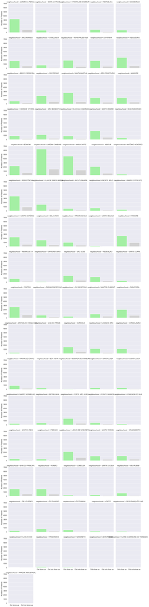

```python
#unsing the previous function to plot the proportion of patients by neoghborhood and no-show
plot_sidebyside("neighbourhood",7000)
```

```python
#Calculating the total number of patients by neighborhood
neigh_total = df.groupby('neighbourhood')['no_show'].count()
neigh_total
```

```
neighbourhood
AEROPORTO                 8
ANDORINHAS             2262
ANTÔNIO HONÓRIO         271
ARIOVALDO FAVALESSA     282
BARRO VERMELHO          423
                       ...
SÃO JOSÉ               1977
SÃO PEDRO              2448
TABUAZEIRO             3132
UNIVERSITÁRIO           152
VILA RUBIM              851
Name: no_show, Length: 81, dtype: int64
```

As the total number of patients is different in each neighbourhood it is more insightful if we plot by proportion

```
neighberhood =  JARDIM DA PENHA
```

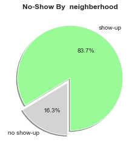

```
neighberhood =  MATA DA PRAIA
```

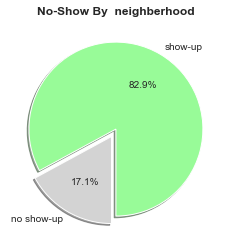

```
neighberhood =  PONTAL DE CAMBURI
```

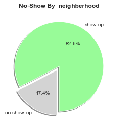

```
neighberhood =  REPÚBLICA
```

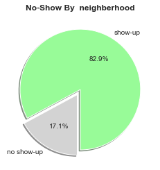

```
neighberhood =  GOIABEIRAS
```

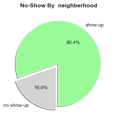

```
neighberhood =  ANDORINHAS
```

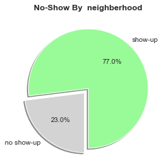

```
neighberhood =  CONQUISTA
```

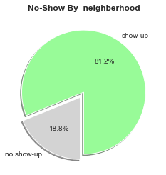

```
neighberhood =  NOVA PALESTINA
```

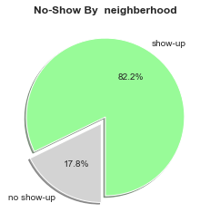

```
neighberhood =  DA PENHA
```

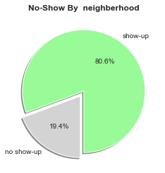

```
neighberhood =  TABUAZEIRO
```

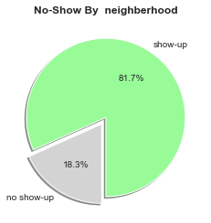

```
neighberhood =  BENTO FERREIRA
```

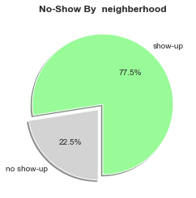

```
neighberhood =  SÃO PEDRO
```

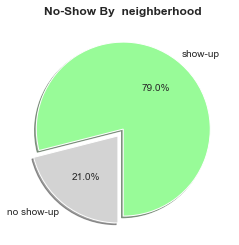

```
neighberhood =  SANTA MARTHA
```

[67 more figures not shown]

```python
#extracting the names of neighborhood from the dataset
neigh_list= df['neighbourhood'].unique()
#plotting a peichart for every neighborhood
for i in neigh_list:
    if len(df_neigh[i]) == 2 :
        print( "neighberhood = ",i)
        #using the previous function: pie_chart(title, expression_to_plot)
        pie_chart('No-Show By  neighberhood',df_neigh[i])
```

Santa Clara

shwoing up : 73.5% not showing up : 26.5%

Santos Dumont

shwoing up : 71.1% not showing up : 28.9%

Santa Cecilia

shwoing up : 72.5% not showing up : 27.5%

There are 2 other exception having a show-up rate above the previous average (90% rounding up to the nearest 10) and a no-show rate lower than the previous average (10% rounding up to the nearest 10)

Ilha Do Boi

shwoing up : 91.4% not showing up : 8.6%

Aeroporto

shwoing up : 87.5% not showing up : 12.5%

```python
#checking the number of patient that these exceptional neighborhoods have
print(neigh_total['FRADINHOS'])
print(neigh_total['SANTA CLARA'])
print(neigh_total['SANTOS DUMONT'])
print(neigh_total['SANTA CECÍLIA'])
print(neigh_total['ILHA DO BOI'])
print(neigh_total['AEROPORTO'])
```

```
258
506
1276
448
35
8
```

we can see that the 2 last neighborhood don't have a representative sample size

## Fifth question to answer

> Do people having scholarship attend more to their consultation because it is free

To go back to the questions section click here

```python
#calculating the proportions by dividing the number of patients grouped by scholarship and by no-show over the total number of patients by scholarship
scholarship_prop= df.groupby('scholarship')['no_show'].value_counts()/df.groupby('scholarship')['no_show'].count()
scholarship_prop
```

```
scholarship  no_show
0            No         0.801928
             Yes        0.198072
1            No         0.762637
             Yes        0.237363
Name: no_show, dtype: float64
```

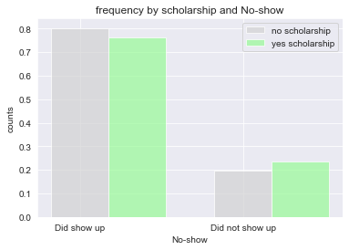

```python
ind = np.arange(2)  # the x locations for the groups
width = 1       # the width of the bars
ind
# plot bars of propotion of patients by scholarship and no-show
noscholar = plt.bar(['Did show up', 'Did not show up'], scholarship_prop[0], 0.35, color='lightgrey', alpha=.7, label='no scholarship')
yesscholar = plt.bar(ind+ 0.35, scholarship_prop[1], 0.35, color='palegreen', alpha=.7, label='yes scholarship')

# title and labels
plt.ylabel('counts')
plt.xlabel('No-show')
plt.title('frequency by scholarship and No-show')
#locations = ind + width / 2  # xtick locations
#labels = ['3', '4', '5', '6', '7', '8', '9']  # xtick labels
# legend
plt.legend();
```

The show up rate is higher with patients who have no sholarship 80% compared to 76% of people who have scholarship and they show-up Thus, people who have scholarship have a higher rate of not showing up 23.7% compared to 19.8%